# BikeSGV Story

Using a just few synoptic and time series data functions, we can investigate something fishy going on with one particular air monitor in northwest Pasadena.

Let’s pull it up by it monitor label, *BikeSGV - West Pasadena*, from a loaded list of US PurpleAir monitors:

```r
library(AirSensor)

pas <- pas_load()
pas_bikesgv <- pas_filter(pas, label == "BikeSGV - West Pasadena")
pas_leaflet(pas_bikesgv)
```

[interactive chart not shown]

While this surface level glance may seem normal at first, the monitor’s past measurements happen to display something very strange. We can gather these readings by loading a PurpleAir Timeseries *pat* object using the same label:

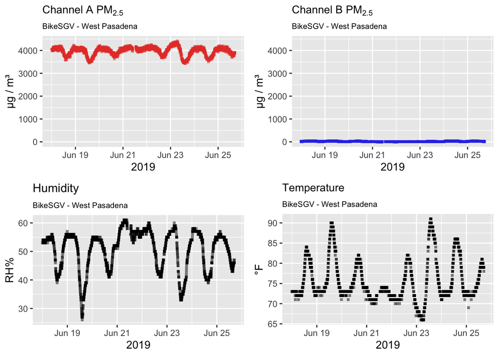

```r
pat_bikesgv <- pat_loadLatest(pas, "BikeSGV - West Pasadena",
                              startdate="2019-06-18", enddate="2019-06-25")
pat_multiplot(pat_bikesgv)
```

This monitor’s A and B sensor channels appear to be telling us two completely different stories! Let’s zoom in on just the PM readings for now and overlay them by setting the plottype:

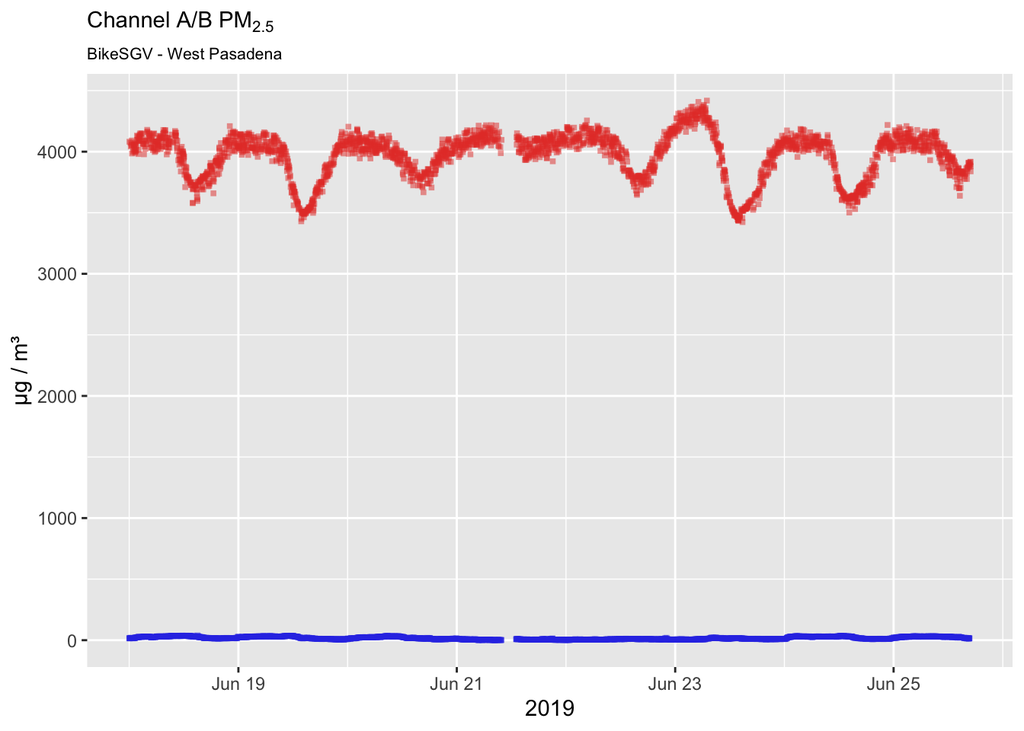

```r
pat_multiplot(pat_bikesgv, plottype = "pm25_over")
```

While the A channel PM 2.5 measurements oscillate over time in a fairly natural manner, they also all measure impossibly high: Around 4000 μg/m³ when anything over 100 μg/m³ on the [AQI](https://www.airnow.gov/index.cfm?action=aqibasics.aqi) is unhealthy! This also skews the plot enough to make the B channel look practically flat, so let’s separate them and take a look at B on its own scale to see if it’s readings are more reasonable:

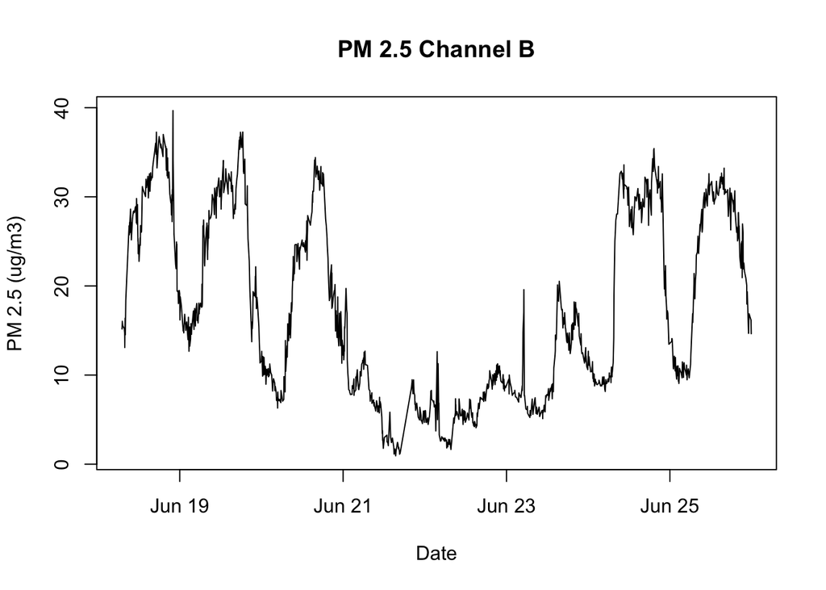

```r
#sampled_b <- pat_bikesvg$data # Unsampled and noisy
#sampled_b <- pat_sample(pat_bikesvg, 5000)$data # Sampled, but draws gaps at NA points
sampled_b <- na.omit(pat_sample(pat_bikesgv, 5000)$data) # Sampled with no gaps, but have to na.omit once sampled
pm25_b <- sampled_b[, c("datetime", "pm25_B")]
plot(pm25_b, type = "l", main = "PM 2.5 Channel B",
     xlab = "Date", ylab = "PM 2.5 (ug/m3)")
```

B channel does look a bit more normal, with just a few spikes here and there never reaching ridiculous levels like channel A. So what *is* the issue with channel A then? Is there any relationship between the channels at all? Let’s generate a linear fit between them and see if maybe they are scaled versions of each other:

[figure not shown]

```
## [1] 1
## NULL
```

```r
pat_internalFit(pat_bikesgv)
```

[output not shown]

It looks like the A ad B channels aren’t linearly correlated at all. This is odd since, ideally, the two sensors should measure exactly the same or at least very similar. Maybe comparing with another sensor could give us some insight. We can check them all against each other at once using a scatterplot:

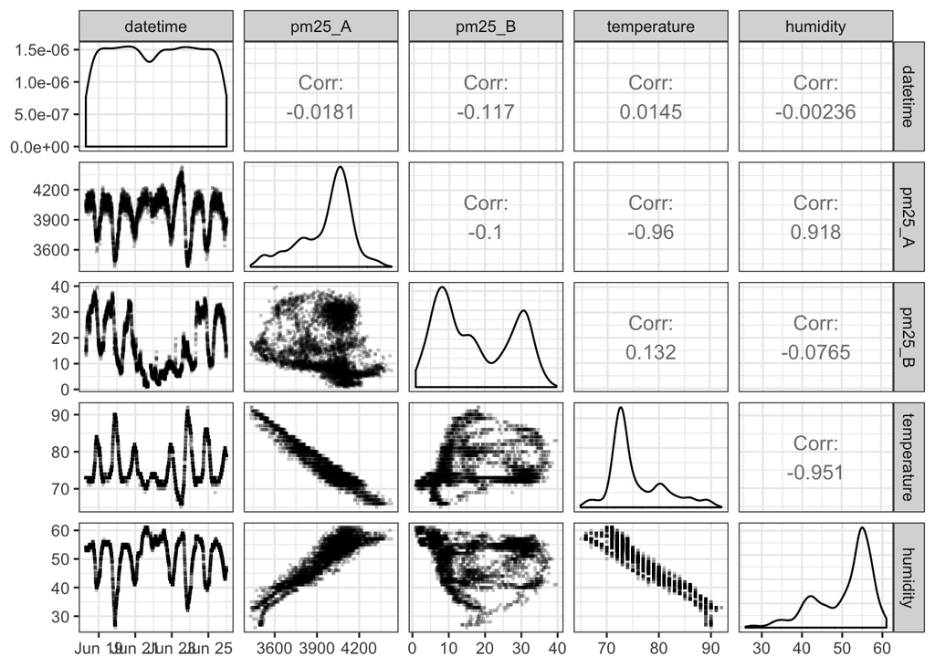

```r
pat_scatterplot(pat_bikesgv)
```

Now we’re getting somewhere! While the correlation plot between the two channels is a shapeless cloud, channel A seems to have a very well defined relationship with temperature and humidity while channel B has no similarities with them at all.

How closely related is channel A to these auxilary sensors though? Let’s first make a linear model between the channel A and temperature:

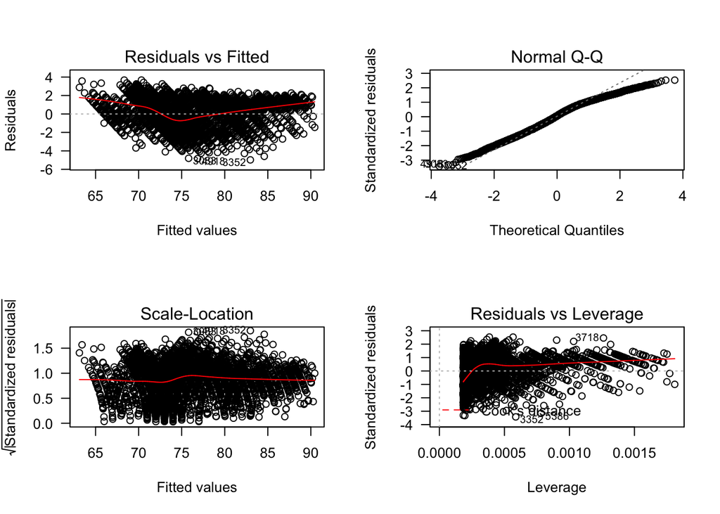

```r
pat_data <- pat_bikesgv$data
model_temp <- lm(temperature ~ pm25_A, data=pat_data)

par(mfrow = c(2, 2), las = 1)
plot(model_temp)
```

```r
summary(model_temp)
```

```
##
## Call:
## lm(formula = temperature ~ pm25_A, data = pat_data)
##
## Residuals:
##     Min      1Q  Median      3Q     Max
## -4.9757 -1.0840  0.0849  1.1806  3.6744
##
## Coefficients:
##               Estimate Std. Error t value Pr(>|t|)
## (Intercept)  1.834e+02  4.250e-01   431.6   <2e-16 ***
## pm25_A      -2.716e-02  1.069e-04  -254.1   <2e-16 ***
## ---
## Signif. codes:  0 '***' 0.001 '**' 0.01 '*' 0.05 '.' 0.1 ' ' 1
##
## Residual standard error: 1.454 on 5449 degrees of freedom
##   (7 observations deleted due to missingness)
## Multiple R-squared:  0.9222, Adjusted R-squared:  0.9222
## F-statistic: 6.456e+04 on 1 and 5449 DF,  p-value: < 2.2e-16
```

That’s a pretty clear linear correlation! I wonder how closely the line graphs would match if we scaled the A channel readings down by applying the linear model coefficients?

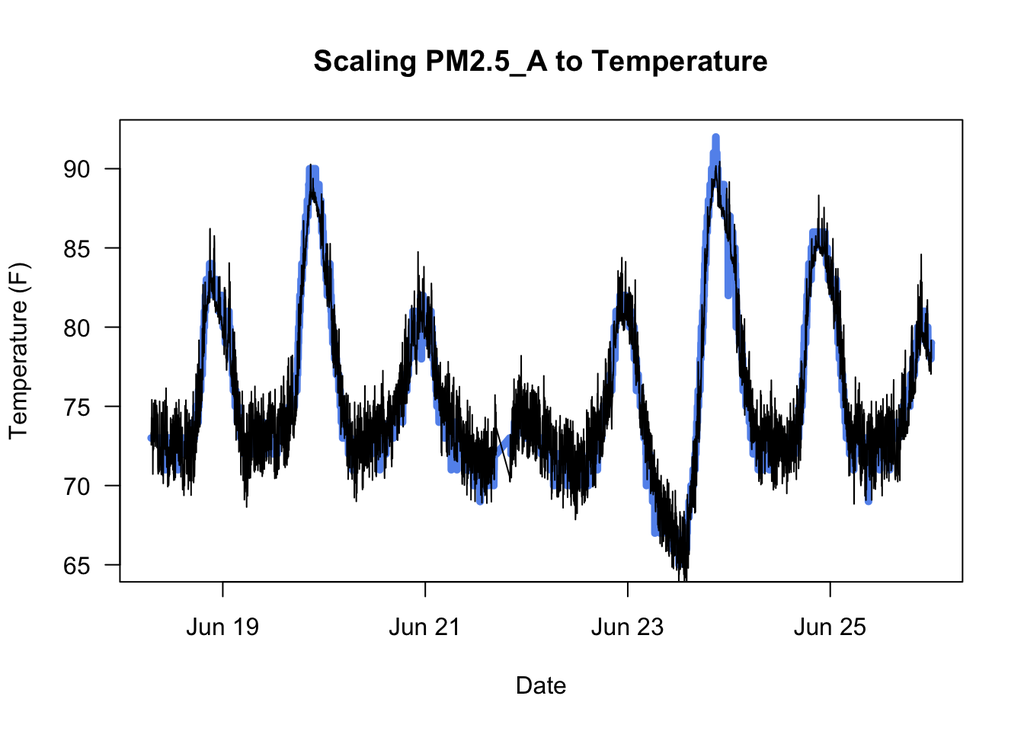

```r
x <- pat_data$datetime
y <- pat_data$temperature
scaled_pm25a <- predict.lm(model_temp, newdata=pat_data)

par(las = 1)
plot(x, y,
     col = "cornflowerblue", lwd = 5, lty = "solid", type = "l",
     main = "Scaling PM2.5_A to Temperature",
     xlab = "Date", ylab = "Temperature (F)")
lines(x, scaled_pm25a, col = "black", lwd = 1)
```

Wow! Although it’s a bit noisy, the A channel definitely matches the general shape of the temperature plot! Let’s see if the same holds when comparing to humidity:

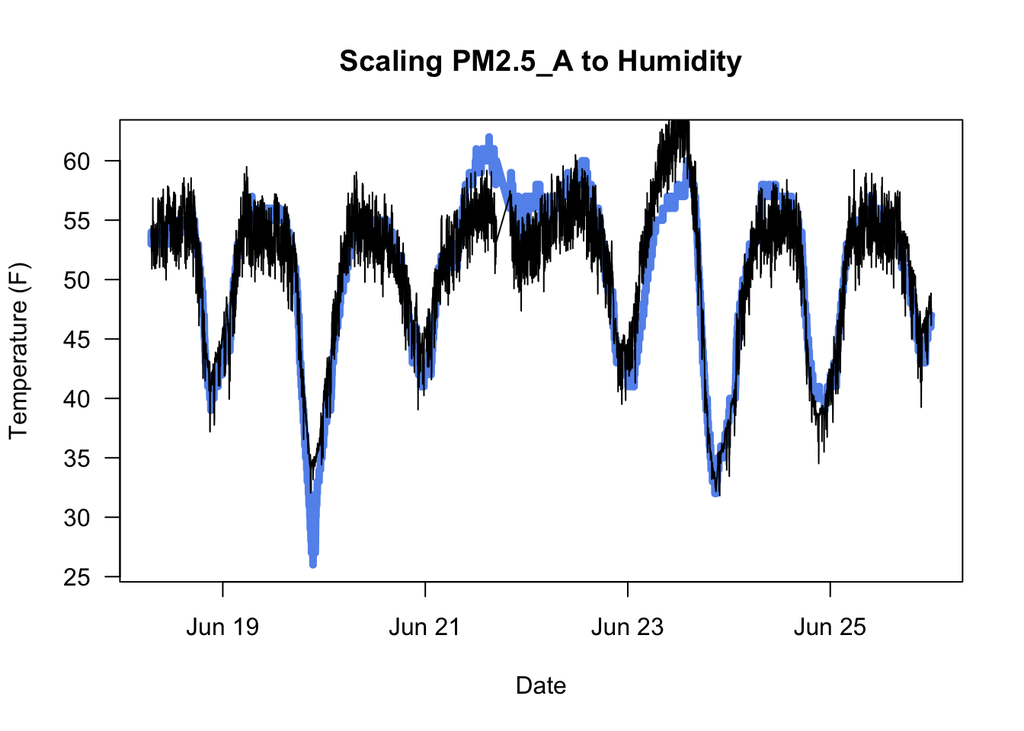

```r
model_humid <- lm(humidity ~ pm25_A, data=pat_data)
x <- pat_data$datetime
y <- pat_data$humidity
scaled_a <- predict.lm(model_humid, newdata=pat_data)

par(las = 1)
plot(x, y,
     col = "cornflowerblue", lwd = 5, lty = "solid", type = "l",
     main = "Scaling PM2.5_A to Humidity",
     xlab = "Date", ylab = "Temperature (F)")
lines(x, scaled_a, col = "black", lwd = 1)
```

Maybe not quite as definite as the temperature comparison, but once again the channel A readings match the trend of the humidity data. Just to be complete, let’s try the same comparson process using the channel B PM 2.5 readings and see if we find a relationship:

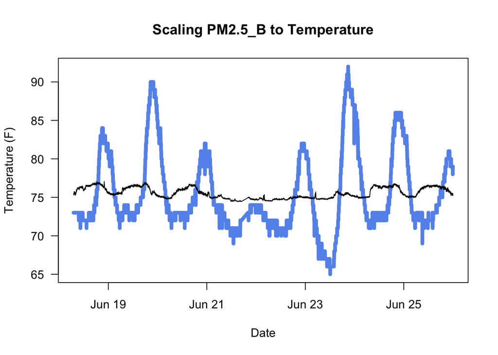

```r
model_temp_b <- lm(temperature ~ pm25_B, data=pat_data)
x <- pat_data$datetime
y <- pat_data$temperature
scaled_b <- predict.lm(model_temp_b, newdata=pat_data)

par(las = 1)
plot(x, y,
     col = "cornflowerblue", lwd = 5, lty = "solid", type = "l",
     main = "Scaling PM2.5_B to Temperature",
     xlab = "Date", ylab = "Temperature (F)")
lines(x, scaled_b, col = "black", lwd = 1)
```

Hmm, not at all. So what is happening with channel A? It almost seems like the temperature or humidity readings have been leaking into the PM 2.5 channel A sensor and overriding its measurements (if it’s still taking any).

So far though we’ve only looked at a week’s worth of questionable data. Has this monitor always been acting this way? Lets load and view readings from earlier this year:

```r
pat_bikesgv <- pat_loadLatest(pas, "BikeSGV - West Pasadena",
                              startdate="2019-04-05", enddate="2019-04-22")

pat_dygraph(pat_bikesgv)
```

[interactive chart not shown]

That answers that question! Before the evening of April 18th, 2019, both channels seemed to agree with each other. Around 7:00 PM though, channel A suddenly switched to the strange state we investigated originally. Channel A also appeared to have some issues between April 7th and 9th which yielded readings in the same 3000-4000 μg/m³ range, but returned to normal for about a week before going bonkers again.

Channel B seemed unaffected by anything the whole time though. Let’s see if the auxilary sensors experienced anything unusual:

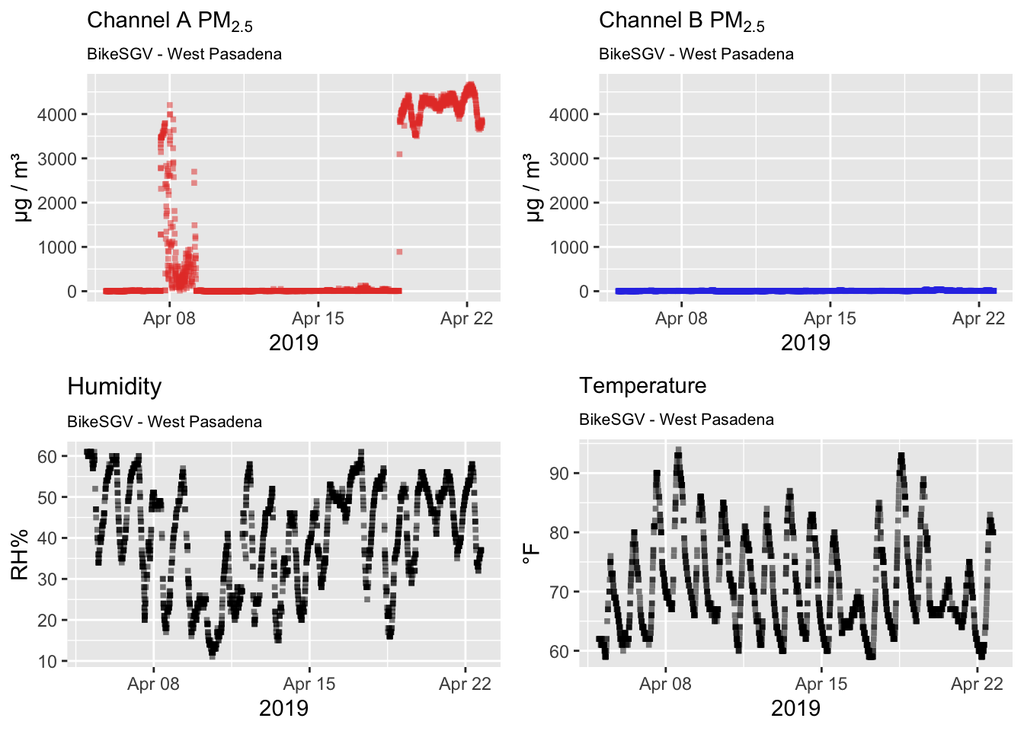

```r
pat_multiplot(pat_bikesgv)
```

THE END